# Homework 11 - mobile app interactivity

Author

Alex Nguyen

Published

April 27, 2025

- [LINK to GITHUB](https://github.com/cmsc-vcu/cmsc427-sp2025-hw11-AlekayPrograms)
- [LINK to FIGMA](https://www.figma.com/board/1ZPKugOH79G67V9fVxGRkA/Habit-Buddy?node-id=0-1)
- [LINK to Snack Editor](https://snack.expo.dev/@alekay/habit-buddy)

# Overview of Habit Buddy

Habit Buddy is a motivational mobile app designed to help users build positive habits through tracking, challenges, and progress visualization. Homework 11 brings interactivity by integrating real-time data updates via React Native hooks, persistent state with global context, and an API fetch using useEffect.

# Key features

- 🔄 Interactive habit buttons using useState
- 📅 Weekly tracker with day toggles
- 🎯 Daily challenge progress entry using modal and input
- 🌙 Theme switching using useContext
- 🧠 State shared globally via context and passed through props
- 🌐 Motivational quote pulled via fetch and useEffect from API Ninjas
- 📱 All features managed within a fully navigable multi-tab layout

# Individual Screen details

## Home Screen

This screen serves as the main dashboard. Users can log completed habits, toggle days in the weekly tracker, and view a motivational quote pulled from an API.

### wireframe design

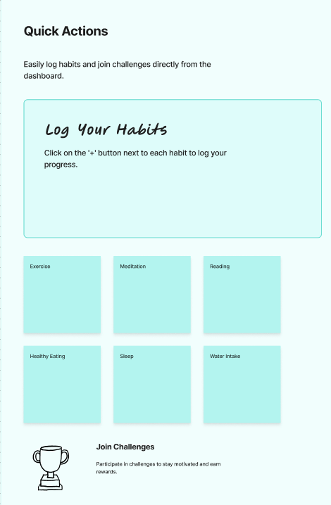

### As-built screenshot

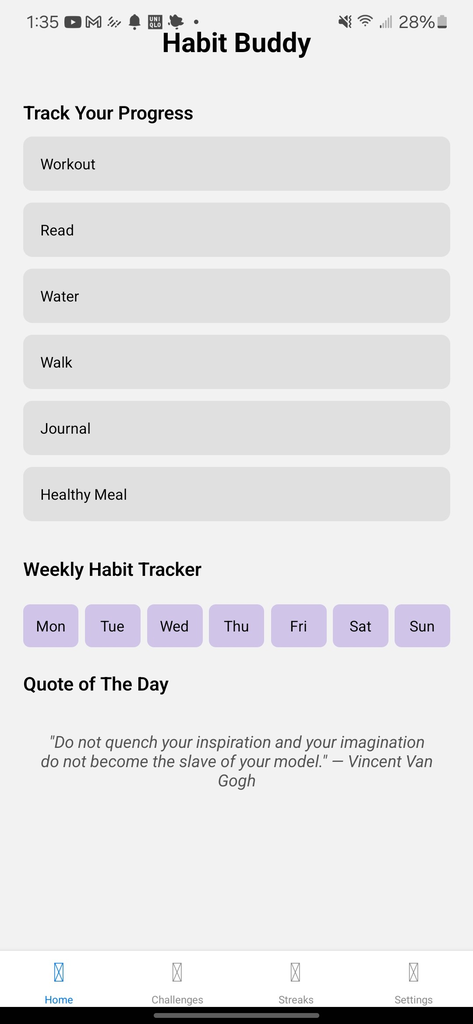

**Interactivity:** - useState manages completed habits and weekly toggles - useContext provides access to global log function and theme - useEffect fetches a motivational quote on load from API Ninjas

## Challenges Screen

Allows users to track specific personal challenges and manually update progress. Reaching the goal marks the challenge complete with a ✅.

### wireframe design

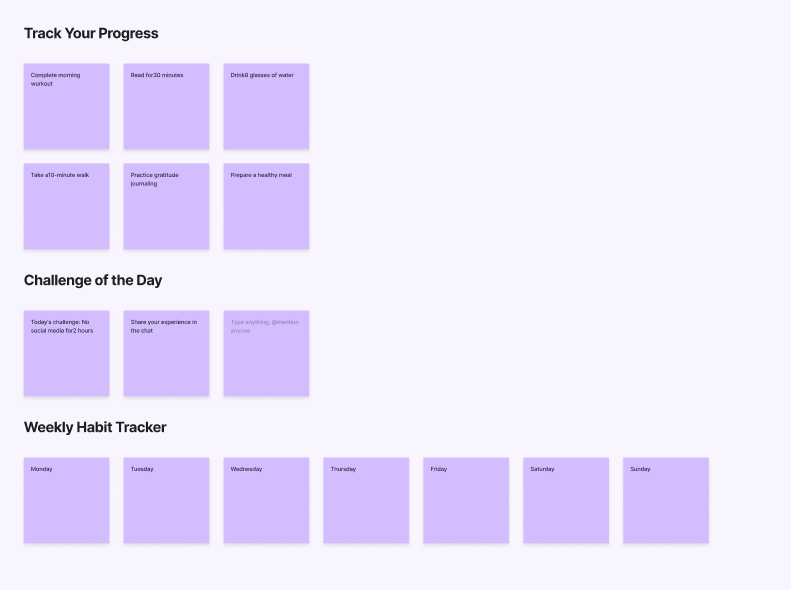

### As-built screenshot

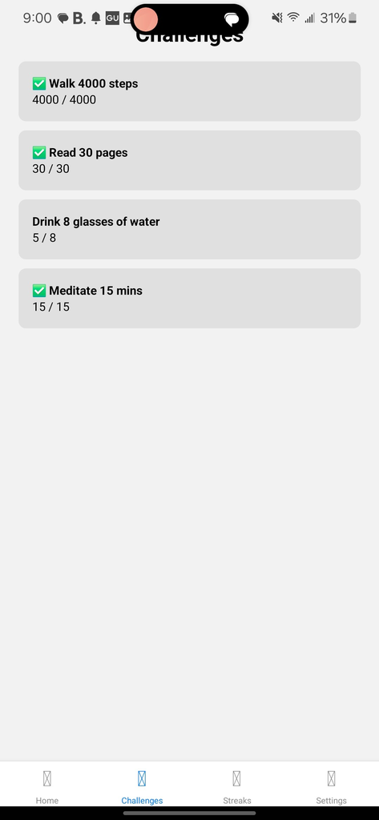

**Interactivity:** - useState for storing and updating challenge progress - Modal used to handle numeric input - Logic to detect goal completion and apply a checkmark

## Streaks Screen

Displays a streak count and a weekly history using emojis.

### wireframe design

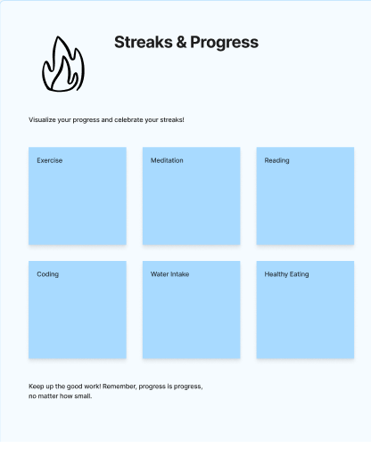

### As-built screenshot

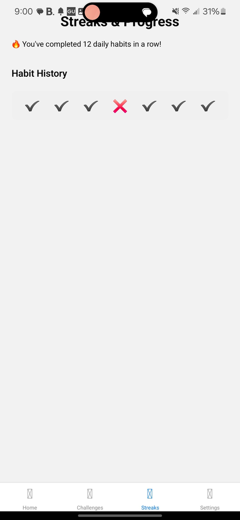

**Interactivity:** - Static display of streak count and habit history - Future improvement could track streaks using dynamic state